# Classification Trees

Lawson Busch

11/13/2018

# Data and Packages

```r
library(ggplot2)
library(dplyr)
land <- read.csv("https://www.macalester.edu/~ajohns24/data/land_cover.csv")

land_sub <- land %>%
    filter(class %in% c("asphalt ","grass ","tree ")) %>%
    mutate(class = droplevels(class))
```

Train and test:

```r
set.seed(3)
index <- sample(c(1:277), size = 222)
train <- land_sub[index, ]
test  <- land_sub[-index, ]
```

# Excercises

## Excercise 1

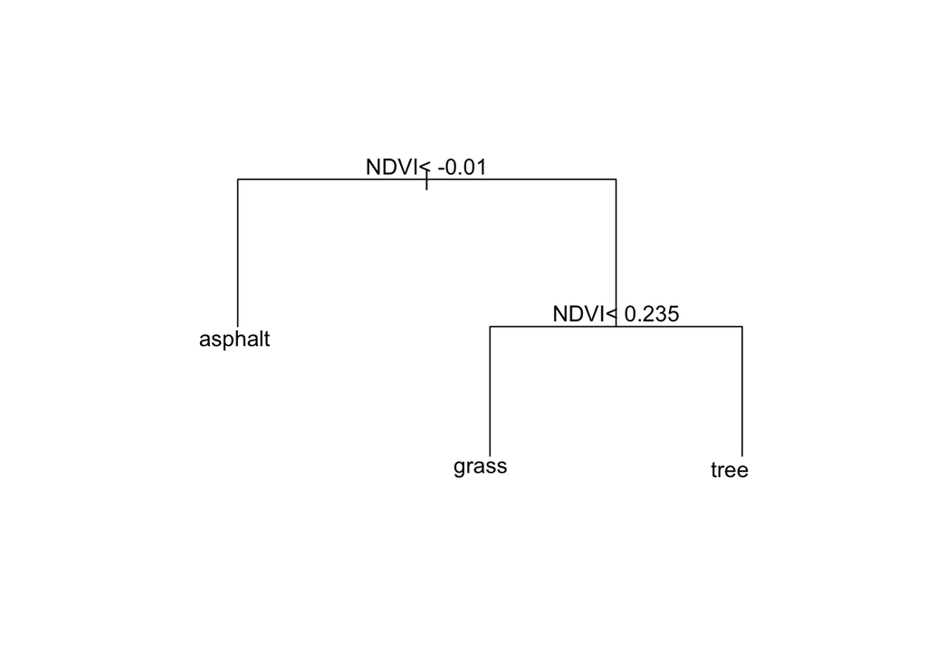

```r
library(rpart)
tree_0 <- rpart(class ~ NDVI, train)
plot(tree_0, margin = 0.2)
text(tree_0)
```

This tree matches up almost exactly with the sketch I drew for class example two, showing that the algorithm is trustworthy.

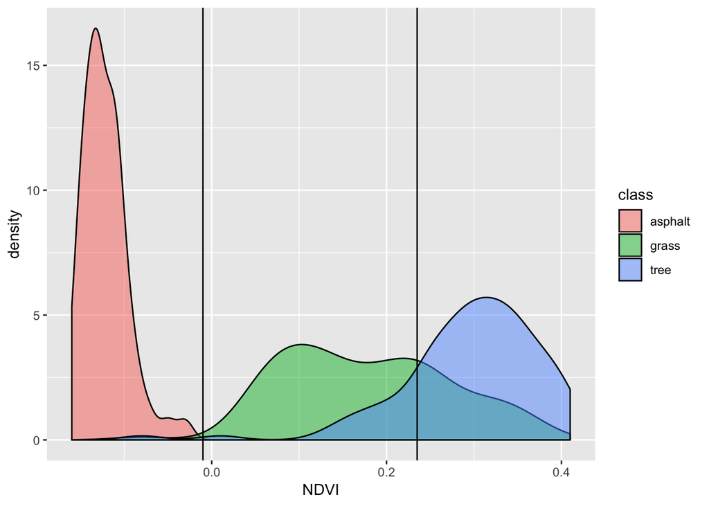

```r
ggplot(land_sub, aes(x = NDVI, fill = class)) +
    geom_density(alpha=0.5) +
    geom_vline(xintercept = -0.01) +
    geom_vline(xintercept = 0.235)
```

## Excercise 2

```r
tree_1 <- rpart(class ~ NDVI + Mean_G, train)
tree_1
```

```
## n= 222
##
## node), split, n, loss, yval, (yprob)
##       * denotes terminal node
##
##  1) root 222 132 grass  (0.22972973 0.40540541 0.36486486)
##    2) NDVI< -0.01 53   2 asphalt  (0.96226415 0.01886792 0.01886792) *
##    3) NDVI>=-0.01 169  80 grass  (0.00000000 0.52662722 0.47337278)
##      6) NDVI< 0.235 73  10 grass  (0.00000000 0.86301370 0.13698630) *
##      7) NDVI>=0.235 96  26 tree  (0.00000000 0.27083333 0.72916667)
##       14) Mean_G>=195.84 45  22 grass  (0.00000000 0.51111111 0.48888889)
##         28) NDVI< 0.325 23   8 grass  (0.00000000 0.65217391 0.34782609) *
##         29) NDVI>=0.325 22   8 tree  (0.00000000 0.36363636 0.63636364) *
##       15) Mean_G< 195.84 51   3 tree  (0.00000000 0.05882353 0.94117647) *
```

```r
summary(tree_1)
```

```
## Call:
## rpart(formula = class ~ NDVI + Mean_G, data = train)
##   n= 222
##
##           CP nsplit rel error    xerror       xstd
## 1 0.37878788      0 1.0000000 1.0757576 0.05419245
## 2 0.33333333      1 0.6212121 0.7878788 0.05632579
## 3 0.02651515      2 0.2878788 0.3106061 0.04380067
## 4 0.01000000      4 0.2348485 0.2954545 0.04295438
##
## Variable importance
##   NDVI Mean_G
##     58     42
##
## Node number 1: 222 observations,    complexity param=0.3787879
##   predicted class=grass     expected loss=0.5945946  P(node) =1
##     class counts:    51    90    81
##    probabilities: 0.230 0.405 0.365
##   left son=2 (53 obs) right son=3 (169 obs)
##   Primary splits:
##       NDVI   < -0.01   to the left,  improve=56.0961, (0 missing)
##       Mean_G < 106.335 to the left,  improve=54.7618, (0 missing)
##   Surrogate splits:
##       Mean_G < 90.29   to the left,  agree=0.977, adj=0.906, (0 split)
##
## Node number 2: 53 observations
##   predicted class=asphalt   expected loss=0.03773585  P(node) =0.2387387
##     class counts:    51     1     1
##    probabilities: 0.962 0.019 0.019
##
## Node number 3: 169 observations,    complexity param=0.3333333
##   predicted class=grass     expected loss=0.4733728  P(node) =0.7612613
##     class counts:     0    89    80
##    probabilities: 0.000 0.527 0.473
##   left son=6 (73 obs) right son=7 (96 obs)
##   Primary splits:
##       NDVI   < 0.235   to the left,  improve=29.083410, (0 missing)
##       Mean_G < 189.03  to the right, improve= 6.913439, (0 missing)
##   Surrogate splits:
##       Mean_G < 230.21  to the right, agree=0.592, adj=0.055, (0 split)
```

[output cut: 27 more lines]

```
##
## Node number 15: 51 observations
##   predicted class=tree      expected loss=0.05882353  P(node) =0.2297297
##     class counts:     0     3    48
##    probabilities: 0.000 0.059 0.941
##
## Node number 28: 23 observations
##   predicted class=grass     expected loss=0.3478261  P(node) =0.1036036
##     class counts:     0    15     8
##    probabilities: 0.000 0.652 0.348
##
## Node number 29: 22 observations
##   predicted class=tree      expected loss=0.3636364  P(node) =0.0990991
##     class counts:     0     8    14
##    probabilities: 0.000 0.364 0.636
```

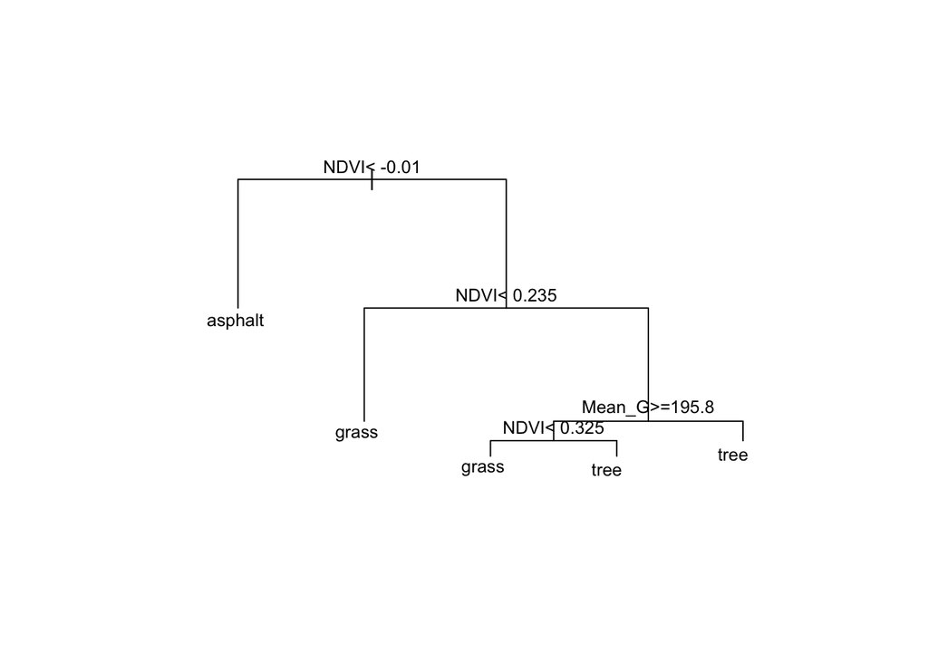

```r
plot(tree_1, margin = 0.2)
text(tree_1, cex = 0.8)
```

Image1: NVDI = -0.05, Mean_G = 175 is asphault.

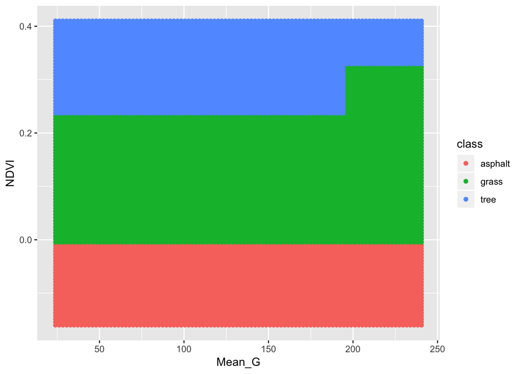

```r
treeplot <- function(model){
    x1 <- train$Mean_G
    x2 <- train$NDVI
    x1s <- seq(min(x1), max(x1), len = 100)
    x2s <- seq(min(x2), max(x2), len = 100)
    testdata <- expand.grid(x1s,x2s) %>%
        mutate(class = predict(model, newdata = data.frame(Mean_G=Var1, NDVI=Var2), type = "class"))
    ggplot(testdata, aes(x = Var1, y = Var2, color = class)) +
        geom_point() +
        labs(y = "NDVI", x = "Mean_G")
}

treeplot(tree_1)
```

## Excercise 3

For the tree classification regions, they are all discrete squares or rectangels, and are larger, more continuous regions. This is not true for KNN, which has many subregions and is not all a square or rectangle.

## Excercise 4

The first rule of NVDI < -0.01 is the best possible rule because everything below that point is asphault, with only a handlful of trees/grass below this cutoff.

The third split of Mean_G >= 195.8 is the best because it shows a split between the remaining trees and grass.

The final split of NVDI < 0.325 helps separate our few remaining data points.

## Excercise 5

```r
pred_1 <- predict(tree_1, newdata = test, type = "class")
true <- test$class

table(pred_1, true)
```

```
##           true
## pred_1     asphalt  grass  tree
##   asphalt         8      0     0
##   grass           0     19     9
##   tree            0      3    16
```

The overall misclassification rate is 12/(8+28+19) = 0.2181818.

Overall, this is a pretty good classification rule.

## Excercise 6

```r
tree_1 <- rpart(class ~ NDVI + Mean_G, train)
tree_2 <- rpart(class ~ NDVI + Mean_G, train, minbucket = 60)
tree_3 <- rpart(class ~ NDVI + Mean_G, train, minbucket = 1, cp = -1)
```

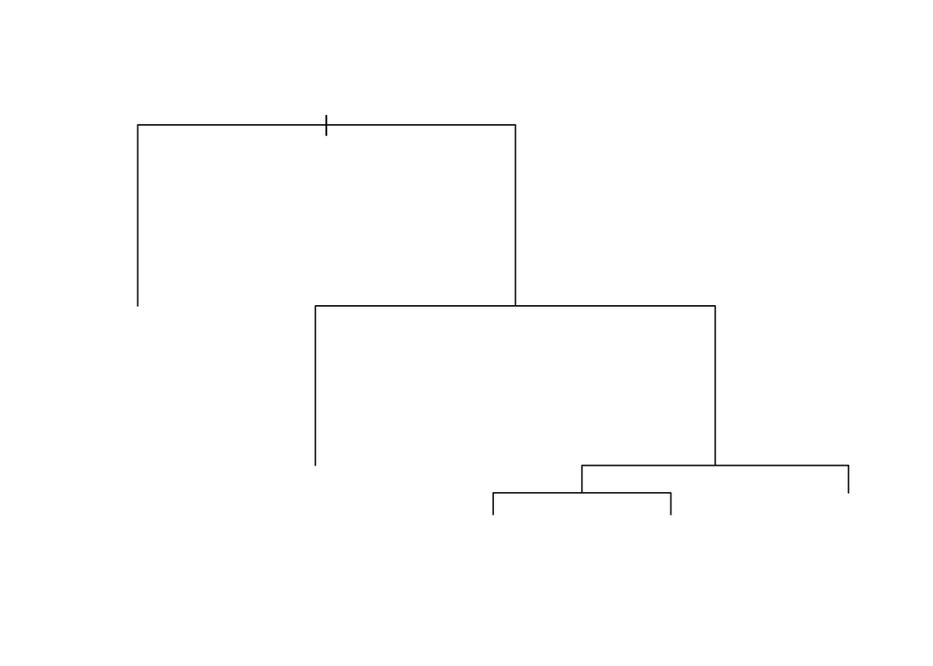

```r
plot(tree_1)
```

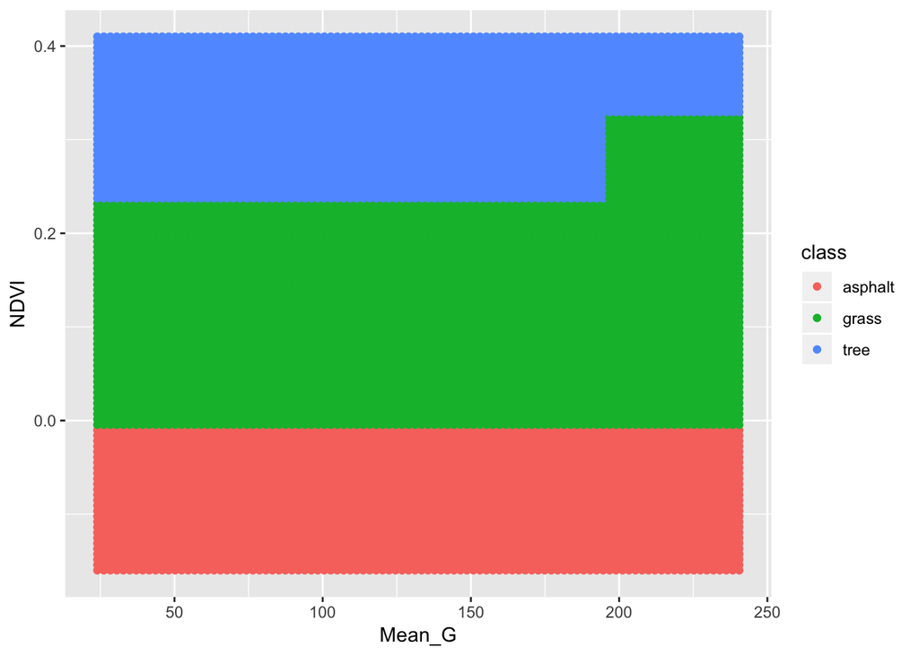

```r
treeplot(tree_1)
```

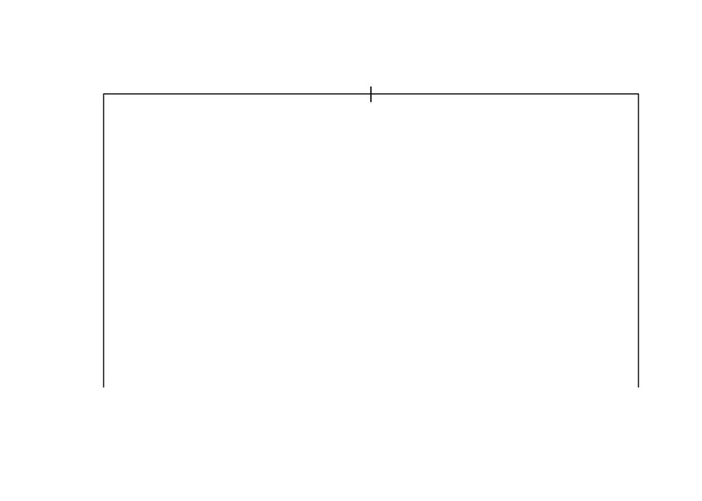

```r
plot(tree_2)
```

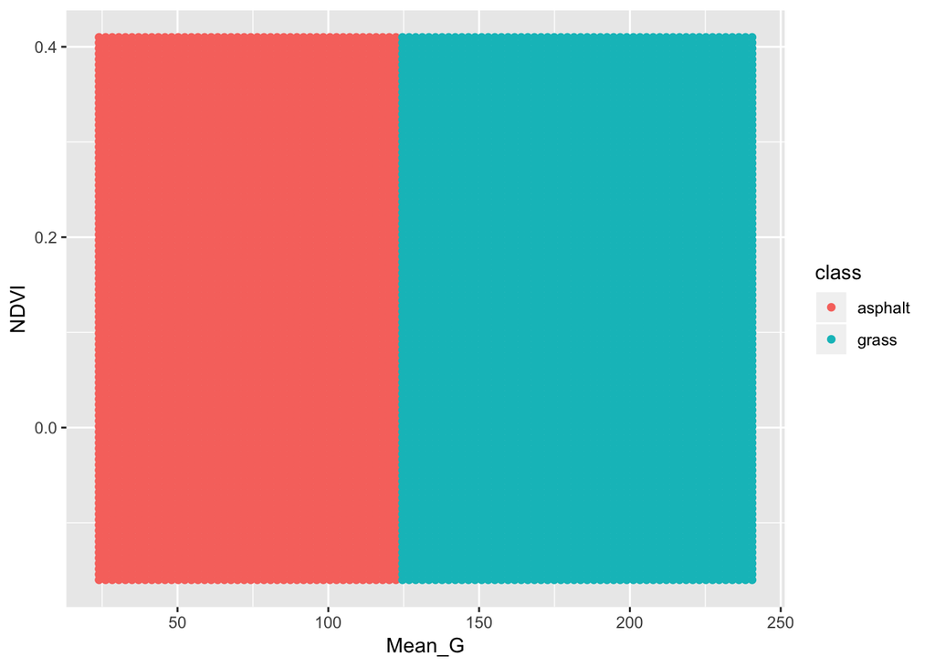

```r
treeplot(tree_2)
```

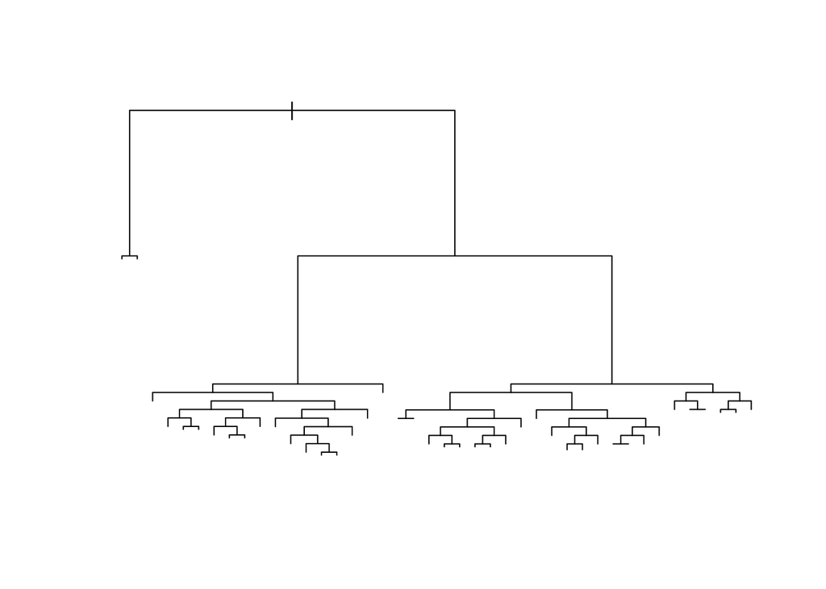

```r
plot(tree_3)
```

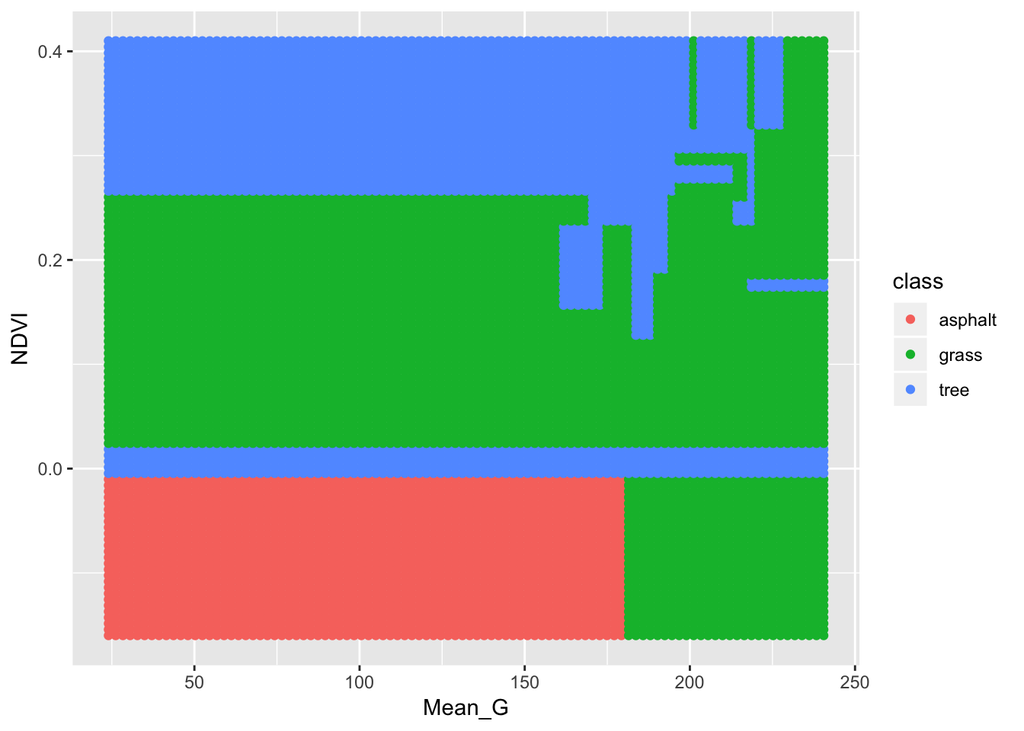

```r
treeplot(tree_3)
```

As we grow a classification tree, we get more accurate classifications. However, it quickly becomes more complicated and has a ton of nodes, making it harder to visualize and see what is going on. If we have too few nodes though, we quickly lose accuracy in the predictions of our data set (as seen in tree_2). As with KNN, there is likely a tradeoff between tree complexity and prediction accuracy.